# Loan Data Exploration

## by Qilin Zhang

1. Preliminary Wrangling
2. Data Wrangling
3. Univariate Exploration
4. Bivariate Exploration
5. Multivariate Exploration

## 1. Preliminary Wrangling

This data set contains 113,937 loans with 81 variables on each loan, including loan amount, borrower rate (or interest rate), current loan status, borrower income, and many others. Please check [Prosper Data Dictionary to Explain Dataset's Variables](https://docs.google.com/spreadsheets/d/1gDyi_L4UvIrLTEC6Wri5nbaMmkGmLQBk-Yx3z0XDEtI/edit#gid=0) for detailed variable explanations.

```python
# import all packages and set plots to be embedded inline
import numpy as np
import pandas as pd
import matplotlib.pyplot as plt
import seaborn as sns
from pandas.api.types import CategoricalDtype

%matplotlib inline
```

```python
# Show all columns
pd.set_option('display.max_columns', None)

# Show at most 80 rows
pd.set_option('display.max_rows', 90)
```

```python
# load dataset
df = pd.read_csv('prosperLoanData.csv')
df.head()
```

|  | ListingKey | ListingNumber | ListingCreationDate | CreditGrade | Term | LoanStatus | ClosedDate | BorrowerAPR | BorrowerRate | LenderYield | EstimatedEffectiveYield | EstimatedLoss | EstimatedReturn | ProsperRating (numeric) | ProsperRating (Alpha) | ProsperScore | ListingCategory (numeric) | BorrowerState | Occupation | EmploymentStatus | EmploymentStatusDuration | IsBorrowerHomeowner | CurrentlyInGroup | GroupKey | DateCreditPulled | CreditScoreRangeLower | CreditScoreRangeUpper | FirstRecordedCreditLine | CurrentCreditLines | … |
| --- | --- | --- | --- | --- | --- | --- | --- | --- | --- | --- | --- | --- | --- | --- | --- | --- | --- | --- | --- | --- | --- | --- | --- | --- | --- | --- | --- | --- | --- | --- |
| 0 | 1021339766868145413AB3B | 193129 | 2007-08-26 19:09:29.263000000 | C | 36 | Completed | 2009-08-14 00:00:00 | 0.16516 | 0.1580 | 0.1380 | NaN | NaN | NaN | NaN | NaN | NaN | 0 | CO | Other | Self-employed | 2.0 | True | True | NaN | 2007-08-26 18:41:46.780000000 | 640.0 | 659.0 | 2001-10-11 00:00:00 | 5.0 | … |
| 1 | 10273602499503308B223C1 | 1209647 | 2014-02-27 08:28:07.900000000 | NaN | 36 | Current | NaN | 0.12016 | 0.0920 | 0.0820 | 0.07960 | 0.0249 | 0.05470 | 6.0 | A | 7.0 | 2 | CO | Professional | Employed | 44.0 | False | False | NaN | 2014-02-27 08:28:14 | 680.0 | 699.0 | 1996-03-18 00:00:00 | 14.0 | … |
| 2 | 0EE9337825851032864889A | 81716 | 2007-01-05 15:00:47.090000000 | HR | 36 | Completed | 2009-12-17 00:00:00 | 0.28269 | 0.2750 | 0.2400 | NaN | NaN | NaN | NaN | NaN | NaN | 0 | GA | Other | Not available | NaN | False | True | 783C3371218786870A73D20 | 2007-01-02 14:09:10.060000000 | 480.0 | 499.0 | 2002-07-27 00:00:00 | NaN | … |
| 3 | 0EF5356002482715299901A | 658116 | 2012-10-22 11:02:35.010000000 | NaN | 36 | Current | NaN | 0.12528 | 0.0974 | 0.0874 | 0.08490 | 0.0249 | 0.06000 | 6.0 | A | 9.0 | 16 | GA | Skilled Labor | Employed | 113.0 | True | False | NaN | 2012-10-22 11:02:32 | 800.0 | 819.0 | 1983-02-28 00:00:00 | 5.0 | … |
| 4 | 0F023589499656230C5E3E2 | 909464 | 2013-09-14 18:38:39.097000000 | NaN | 36 | Current | NaN | 0.24614 | 0.2085 | 0.1985 | 0.18316 | 0.0925 | 0.09066 | 3.0 | D | 4.0 | 2 | MN | Executive | Employed | 44.0 | True | False | NaN | 2013-09-14 18:38:44 | 680.0 | 699.0 | 2004-02-20 00:00:00 | 19.0 | … |

```python
df.shape
```

```
(113937, 81)
```

```python
df.info()
```

```
<class 'pandas.core.frame.DataFrame'>
RangeIndex: 113937 entries, 0 to 113936
Data columns (total 81 columns):
 #   Column                               Non-Null Count   Dtype
---  ------                               --------------   -----
 0   ListingKey                           113937 non-null  object
 1   ListingNumber                        113937 non-null  int64
 2   ListingCreationDate                  113937 non-null  object
 3   CreditGrade                          28953 non-null   object
 4   Term                                 113937 non-null  int64
 5   LoanStatus                           113937 non-null  object
 6   ClosedDate                           55089 non-null   object
 7   BorrowerAPR                          113912 non-null  float64
 8   BorrowerRate                         113937 non-null  float64
 9   LenderYield                          113937 non-null  float64
```

[output cut: 73 more lines]

```python
df.describe()
```

|  | ListingNumber | Term | BorrowerAPR | BorrowerRate | LenderYield | EstimatedEffectiveYield | EstimatedLoss | EstimatedReturn | ProsperRating (numeric) | ProsperScore | ListingCategory (numeric) | EmploymentStatusDuration | CreditScoreRangeLower | CreditScoreRangeUpper | CurrentCreditLines | OpenCreditLines | TotalCreditLinespast7years | OpenRevolvingAccounts | OpenRevolvingMonthlyPayment | InquiriesLast6Months | TotalInquiries | CurrentDelinquencies | AmountDelinquent | DelinquenciesLast7Years | PublicRecordsLast10Years | PublicRecordsLast12Months | RevolvingCreditBalance | BankcardUtilization | AvailableBankcardCredit | … |
| --- | --- | --- | --- | --- | --- | --- | --- | --- | --- | --- | --- | --- | --- | --- | --- | --- | --- | --- | --- | --- | --- | --- | --- | --- | --- | --- | --- | --- | --- | --- |
| count | 1.139370e+05 | 113937.000000 | 113912.000000 | 113937.000000 | 113937.000000 | 84853.000000 | 84853.000000 | 84853.000000 | 84853.000000 | 84853.000000 | 113937.000000 | 106312.000000 | 113346.000000 | 113346.000000 | 106333.000000 | 106333.000000 | 113240.000000 | 113937.00000 | 113937.000000 | 113240.000000 | 112778.000000 | 113240.000000 | 106315.000000 | 112947.000000 | 113240.000000 | 106333.000000 | 1.063330e+05 | 106333.000000 | 106393.000000 | … |
| mean | 6.278857e+05 | 40.830248 | 0.218828 | 0.192764 | 0.182701 | 0.168661 | 0.080306 | 0.096068 | 4.072243 | 5.950067 | 2.774209 | 96.071582 | 685.567731 | 704.567731 | 10.317192 | 9.260164 | 26.754539 | 6.96979 | 398.292161 | 1.435085 | 5.584405 | 0.592052 | 984.507059 | 4.154984 | 0.312646 | 0.015094 | 1.759871e+04 | 0.561309 | 11210.225447 | … |
| std | 3.280762e+05 | 10.436212 | 0.080364 | 0.074818 | 0.074516 | 0.068467 | 0.046764 | 0.030403 | 1.673227 | 2.376501 | 3.996797 | 94.480605 | 66.458275 | 66.458275 | 5.457866 | 5.022644 | 13.637871 | 4.63097 | 447.159711 | 2.437507 | 6.429946 | 1.978707 | 7158.270157 | 10.160216 | 0.727868 | 0.154092 | 3.293640e+04 | 0.317918 | 19818.361309 | … |
| min | 4.000000e+00 | 12.000000 | 0.006530 | 0.000000 | -0.010000 | -0.182700 | 0.004900 | -0.182700 | 1.000000 | 1.000000 | 0.000000 | 0.000000 | 0.000000 | 19.000000 | 0.000000 | 0.000000 | 2.000000 | 0.00000 | 0.000000 | 0.000000 | 0.000000 | 0.000000 | 0.000000 | 0.000000 | 0.000000 | 0.000000 | 0.000000e+00 | 0.000000 | 0.000000 | … |
| 25% | 4.009190e+05 | 36.000000 | 0.156290 | 0.134000 | 0.124200 | 0.115670 | 0.042400 | 0.074080 | 3.000000 | 4.000000 | 1.000000 | 26.000000 | 660.000000 | 679.000000 | 7.000000 | 6.000000 | 17.000000 | 4.00000 | 114.000000 | 0.000000 | 2.000000 | 0.000000 | 0.000000 | 0.000000 | 0.000000 | 0.000000 | 3.121000e+03 | 0.310000 | 880.000000 | … |
| 50% | 6.005540e+05 | 36.000000 | 0.209760 | 0.184000 | 0.173000 | 0.161500 | 0.072400 | 0.091700 | 4.000000 | 6.000000 | 1.000000 | 67.000000 | 680.000000 | 699.000000 | 10.000000 | 9.000000 | 25.000000 | 6.00000 | 271.000000 | 1.000000 | 4.000000 | 0.000000 | 0.000000 | 0.000000 | 0.000000 | 0.000000 | 8.549000e+03 | 0.600000 | 4100.000000 | … |
| 75% | 8.926340e+05 | 36.000000 | 0.283810 | 0.250000 | 0.240000 | 0.224300 | 0.112000 | 0.116600 | 5.000000 | 8.000000 | 3.000000 | 137.000000 | 720.000000 | 739.000000 | 13.000000 | 12.000000 | 35.000000 | 9.00000 | 525.000000 | 2.000000 | 7.000000 | 0.000000 | 0.000000 | 3.000000 | 0.000000 | 0.000000 | 1.952100e+04 | 0.840000 | 13180.000000 | … |
| max | 1.255725e+06 | 60.000000 | 0.512290 | 0.497500 | 0.492500 | 0.319900 | 0.366000 | 0.283700 | 7.000000 | 11.000000 | 20.000000 | 755.000000 | 880.000000 | 899.000000 | 59.000000 | 54.000000 | 136.000000 | 51.00000 | 14985.000000 | 105.000000 | 379.000000 | 83.000000 | 463881.000000 | 99.000000 | 38.000000 | 20.000000 | 1.435667e+06 | 5.950000 | 646285.000000 | … |

### What is the structure of your dataset?

There are 113,937 loan records in the dataset with 81 features. Most variables are numeric in nature, some are nominal variables, such as Occupation, Employment Status and some are Boolean variables regarding questions like whether borrower is homeowner, whether borrower's income verifiable, whether borrower is currently in a group.

### What is/are the main feature(s) of interest in your dataset?

I'm most interested in figuring out what factors affect a loan’s outcome status, and what affects the borrower’s APR or interest rate in the dataset.

### What features in the dataset do you think will help support your investigation into your feature(s) of interest?

- I expect that income, loan amount and credit score will affect loan's outcome status: individuals that have a smaller loan, higher income or higher credit scor are more likely to clear off loans. There might be other variables related, such as whether borrower is homeowner, debt to income ratio,
- Regarding borrower's interest rate, borrower's income is supposed to be related. The lower the borrower's income, the higher the loan interest rate.

## 2. Data Wrangling

In this part, I will do data preparation for analysing, focusing on dealing with duplicated data, categorise loan status and drop variables that will not include in analysis.

```python
# Save a copy of dataset
df_clean = df.copy()
df_clean.shape
```

```
(113937, 81)
```

### 2.1 Duplicated Data

```python
# check duplicated data in whole dataset
df_clean.duplicated().sum()
```

```
0
```

There's no duplicated data in the dataset, while considering that the dataset involves many variables, it's better to check the unique key of data, such as ListingKey or ListingNumber.

```python
df_clean.ListingNumber.duplicated().sum()
```

```
871
```

There are 871 duplicated data.

```python
df_clean[df_clean.ListingKey.duplicated(keep=False)].sort_values(by=['ListingKey']).head(10)
```

|  | ListingKey | ListingNumber | ListingCreationDate | CreditGrade | Term | LoanStatus | ClosedDate | BorrowerAPR | BorrowerRate | LenderYield | EstimatedEffectiveYield | EstimatedLoss | EstimatedReturn | ProsperRating (numeric) | ProsperRating (Alpha) | ProsperScore | ListingCategory (numeric) | BorrowerState | Occupation | EmploymentStatus | EmploymentStatusDuration | IsBorrowerHomeowner | CurrentlyInGroup | GroupKey | DateCreditPulled | CreditScoreRangeLower | CreditScoreRangeUpper | FirstRecordedCreditLine | CurrentCreditLines | … |
| --- | --- | --- | --- | --- | --- | --- | --- | --- | --- | --- | --- | --- | --- | --- | --- | --- | --- | --- | --- | --- | --- | --- | --- | --- | --- | --- | --- | --- | --- | --- |
| 32680 | 00223594917038064A7C947 | 998257 | 2013-11-15 16:58:37.167000000 | NaN | 36 | Current | NaN | 0.23540 | 0.1980 | 0.1880 | 0.17416 | 0.0849 | 0.08926 | 4.0 | C | 5.0 | 1 | NY | Other | Employed | 69.0 | False | False | NaN | 2013-11-04 15:15:31 | 660.0 | 679.0 | 2003-09-07 00:00:00 | 18.0 | … |
| 32681 | 00223594917038064A7C947 | 998257 | 2013-11-15 16:58:37.167000000 | NaN | 36 | Current | NaN | 0.23540 | 0.1980 | 0.1880 | 0.17416 | 0.0849 | 0.08926 | 4.0 | C | 6.0 | 1 | NY | Other | Employed | 69.0 | False | False | NaN | 2013-11-04 15:15:31 | 660.0 | 679.0 | 2003-09-07 00:00:00 | 18.0 | … |
| 32964 | 00473590513960687DD308F | 941296 | 2013-10-07 15:47:36.023000000 | NaN | 60 | Current | NaN | 0.22242 | 0.1980 | 0.1880 | 0.17416 | 0.0849 | 0.08926 | 4.0 | C | 4.0 | 1 | TX | Nurse (RN) | Employed | 218.0 | True | False | NaN | 2013-10-07 15:47:39 | 660.0 | 679.0 | 1990-06-04 00:00:00 | 21.0 | … |
| 17274 | 00473590513960687DD308F | 941296 | 2013-10-07 15:47:36.023000000 | NaN | 60 | Current | NaN | 0.22242 | 0.1980 | 0.1880 | 0.17416 | 0.0849 | 0.08926 | 4.0 | C | 6.0 | 1 | TX | Nurse (RN) | Employed | 218.0 | True | False | NaN | 2013-10-07 15:47:39 | 660.0 | 679.0 | 1990-06-04 00:00:00 | 21.0 | … |
| 7478 | 0098360461900952056DB93 | 1190614 | 2014-03-02 14:21:39.583000000 | NaN | 36 | Current | NaN | 0.29660 | 0.2574 | 0.2474 | 0.22530 | 0.1325 | 0.09280 | 2.0 | E | 2.0 | 1 | VA | Professional | Employed | 4.0 | False | False | NaN | 2014-03-02 14:21:42 | 640.0 | 659.0 | 2002-12-03 00:00:00 | 23.0 | … |
| 33220 | 0098360461900952056DB93 | 1190614 | 2014-03-02 14:21:39.583000000 | NaN | 36 | Current | NaN | 0.29660 | 0.2574 | 0.2474 | 0.22530 | 0.1325 | 0.09280 | 2.0 | E | 4.0 | 1 | VA | Professional | Employed | 4.0 | False | False | NaN | 2014-03-02 14:21:42 | 640.0 | 659.0 | 2002-12-03 00:00:00 | 23.0 | … |
| 27677 | 01163604029146842E28D9C | 1233732 | 2014-02-25 14:33:39.830000000 | NaN | 36 | Current | NaN | 0.31975 | 0.2800 | 0.2700 | 0.24550 | 0.1475 | 0.09800 | 2.0 | E | 2.0 | 1 | NE | Other | Employed | 4.0 | True | False | NaN | 2014-02-23 18:05:46 | 680.0 | 699.0 | 2005-05-12 00:00:00 | 9.0 | … |
| 788 | 01163604029146842E28D9C | 1233732 | 2014-02-25 14:33:39.830000000 | NaN | 36 | Current | NaN | 0.31975 | 0.2800 | 0.2700 | 0.24550 | 0.1475 | 0.09800 | 2.0 | E | 3.0 | 1 | NE | Other | Employed | 4.0 | True | False | NaN | 2014-02-23 18:05:46 | 680.0 | 699.0 | 2005-05-12 00:00:00 | 9.0 | … |
| 27360 | 014F35910923350802E1B29 | 930618 | 2013-09-26 16:44:24.163000000 | NaN | 60 | Current | NaN | 0.19323 | 0.1695 | 0.1595 | 0.14963 | 0.0649 | 0.08473 | 4.0 | C | 4.0 | 1 | WA | Executive | Employed | 41.0 | False | False | NaN | 2013-10-28 13:42:58 | 660.0 | 679.0 | 2000-04-09 00:00:00 | 7.0 | … |
| 18324 | 014F35910923350802E1B29 | 930618 | 2013-09-26 16:44:24.163000000 | NaN | 60 | Current | NaN | 0.19323 | 0.1695 | 0.1595 | 0.14963 | 0.0649 | 0.08473 | 4.0 | C | 7.0 | 1 | WA | Executive | Employed | 41.0 | False | False | NaN | 2013-10-28 13:42:58 | 660.0 | 679.0 | 2000-04-09 00:00:00 | 7.0 | … |

By scrutiny of duplicated data, the duplication issue is caused by a variable 'ProperScore' (A custom risk score built using historical Prosper data. The score ranges from 1-10, with 10 being the best, or lowest risk score). As there's no futher infomation to revise the dataset and this variable could be represented by ProsperRating, I decide to drop this variable and then drop the duplicated.

```python
# Drop variable ProsperScore
df_clean.drop(columns=['ProsperScore'],inplace=True)

# Drop duplicates
df_clean.drop_duplicates(inplace=True)

# Check if there's other issue causing duplicated
df_clean.ListingNumber.duplicated().sum()
```

```
0
```

```python
# New data shape
df_clean.shape
```

```
(113066, 80)
```

### 2.2 Categorise loan status

```python
df_clean.LoanStatus.value_counts()
```

```
Current                   55730
Completed                 38061
Chargedoff                11992
Defaulted                  5018
Past Due (1-15 days)        800
Past Due (31-60 days)       361
Past Due (61-90 days)       311
Past Due (91-120 days)      304
Past Due (16-30 days)       265
FinalPaymentInProgress      203
Past Due (>120 days)         16
Cancelled                     5
Name: LoanStatus, dtype: int64
```

Loan Status have 12 categories, namely Current, Completed, Chargedoff, Defaulted, Past Due (1-15 days), Past Due (31-60 days), Past Due (61-90 days), Past Due (91-120 days), Past Due (16-30 days), FinalPaymentInProgress, Past Due (>120 days), Cancelled. These data will be classified into three general groups: Current, Completed and Defaulted.

Completed loans, loans with final payment in progress and loans regarding Past Due are defined as Completed, considering that investors had no monetary loss. Loans that are Chargedoff and Defaulted are grouped together as Defaulted because investors lost their money. Cancelled data will be deleted as they cannot provide infomation for this analysis. These adjustments are shown through a new variable 'Status'.

```python
# Drop cancelled loans
df_clean=df_clean[df_clean['LoanStatus']!='Cancelled']

# Check
df_clean.LoanStatus.value_counts()
```

```
Current                   55730
Completed                 38061
Chargedoff                11992
Defaulted                  5018
Past Due (1-15 days)        800
Past Due (31-60 days)       361
Past Due (61-90 days)       311
Past Due (91-120 days)      304
Past Due (16-30 days)       265
FinalPaymentInProgress      203
Past Due (>120 days)         16
Name: LoanStatus, dtype: int64
```

```python
# Define new status varible 'Status'
# First set all as Completed
df_clean['Status'] = 'Completed'

# Revise to Current
df_clean.loc[df_clean.LoanStatus=='Current', 'Status']='Current'

# Revise to Defaulted
df_clean.loc[df_clean.LoanStatus=='Defaulted', 'Status']='Defaulted'
df_clean.loc[df_clean.LoanStatus=='Chargedoff', 'Status']='Defaulted'

# Check
df_clean.Status.value_counts()
```

```
Current      55730
Completed    40321
Defaulted    17010
Name: Status, dtype: int64
```

### 2.3 Drop useless variables

Besides the varible dropped in previous section, this dataset have 80 varibles, from which I select 23 varibles for this project.

```python
# Keep important variables
df_clean = df_clean.filter(['ListingKey','ListingCreationDate','Term',
                            'Status','LoanStatus','BorrowerRate',
                            'ListingCategory (numeric)','BorrowerState', 'ProsperRating (Alpha)',
                            'EmploymentStatus', 'EmploymentStatusDuration','IsBorrowerHomeowner',
                            'CreditScoreRangeLower','CreditScoreRangeUpper','InquiriesLast6Months',
                            'DelinquenciesLast7Years','DebtToIncomeRatio','IncomeRange',
                            'IncomeVerifiable','StatedMonthlyIncome',
                            'LoanOriginalAmount','LoanOriginationDate','MonthlyLoanPayment'], axis=1)
```

```python
df_clean.isnull().sum()
```

```
ListingKey                       0
ListingCreationDate              0
Term                             0
Status                           0
LoanStatus                       0
BorrowerRate                     0
ListingCategory (numeric)        0
BorrowerState                 5512
ProsperRating (Alpha)        29079
EmploymentStatus              2252
EmploymentStatusDuration      7621
IsBorrowerHomeowner              0
CreditScoreRangeLower          590
CreditScoreRangeUpper          590
InquiriesLast6Months           696
DelinquenciesLast7Years        987
DebtToIncomeRatio             8472
IncomeRange                      0
IncomeVerifiable                 0
StatedMonthlyIncome              0
LoanOriginalAmount               0
LoanOriginationDate              0
MonthlyLoanPayment               0
dtype: int64
```

```python
# Rename ListingCategory (numeric) to shorter name.
df_clean.rename(columns={"ListingCategory (numeric)": "ListingCategory", "ProsperRating (Alpha)": "ProsperRating"},inplace=True)
```

### 2.4 Adjust Dat Type

Change 'ListingCreationDate' and 'LoanOriginationDate' to datetime.

```python
# Change 'ListingCreationDate' and 'LoanOriginationDate' to datetime.
df_clean['ListingCreationDate']= pd.to_datetime(df_clean['ListingCreationDate'])
df_clean['LoanOriginationDate']= pd.to_datetime(df_clean['LoanOriginationDate'])
```

```python
# Check dtype
df_clean.info()
```

```
<class 'pandas.core.frame.DataFrame'>
Int64Index: 113061 entries, 0 to 113936
Data columns (total 23 columns):
 #   Column                    Non-Null Count   Dtype
---  ------                    --------------   -----
 0   ListingKey                113061 non-null  object
 1   ListingCreationDate       113061 non-null  datetime64[ns]
 2   Term                      113061 non-null  int64
 3   Status                    113061 non-null  object
 4   LoanStatus                113061 non-null  object
 5   BorrowerRate              113061 non-null  float64
 6   ListingCategory           113061 non-null  int64
 7   BorrowerState             107549 non-null  object
 8   ProsperRating             83982 non-null   object
 9   EmploymentStatus          110809 non-null  object
 10  EmploymentStatusDuration  105440 non-null  float64
 11  IsBorrowerHomeowner       113061 non-null  bool
 12  CreditScoreRangeLower     112471 non-null  float64
 13  CreditScoreRangeUpper     112471 non-null  float64
 14  InquiriesLast6Months      112365 non-null  float64
 15  DelinquenciesLast7Years   112074 non-null  float64
 16  DebtToIncomeRatio         104589 non-null  float64
 17  IncomeRange               113061 non-null  object
 18  IncomeVerifiable          113061 non-null  bool
 19  StatedMonthlyIncome       113061 non-null  float64
 20  LoanOriginalAmount        113061 non-null  int64
 21  LoanOriginationDate       113061 non-null  datetime64[ns]
 22  MonthlyLoanPayment        113061 non-null  float64
dtypes: bool(2), datetime64[ns](2), float64(9), int64(3), object(7)
memory usage: 19.2+ MB
```

```python
df_clean.shape
```

```
(113061, 23)
```

Therefore, this report will be based on 113061 records and 23 variables.

## 3. Univariate Exploration

### 3.1 Loan Status

```python
status_count = df_clean.Status.value_counts()
status_count
```

```
Current      55730
Completed    40321
Defaulted    17010
Name: Status, dtype: int64
```

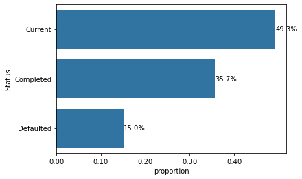

```python
# Get index of ordered series
status_order = status_count.index

# Returns the sum of all not-null values in `Status` column
n_loans = status_count.sum()

# Return the highest frequency in the `Status` column
max_loan_count = status_count[0]

# Return the maximum proportion, or in other words,
# compute the length of the longest bar in terms of the proportion
max_loan_prop = max_loan_count / n_loans

# Use numpy.arange() function to produce a set of evenly spaced proportioned values
tick_props = np.arange(0, max_loan_prop, 0.1)
# Set tick labels.
tick_names = ['{:0.2f}'.format(v) for v in tick_props]

# Set seaborn in single color. Choose the first tuple of RGB colors
base_color = sns.color_palette()[0]

# Plot the proportions
sns.countplot(data=df_clean,y='Status', color=base_color,order=status_order);
plt.xticks(tick_props * n_loans, tick_names)
plt.xlabel('proportion');

# Logic to print the proportion text on the bars
for i in range (status_count.shape[0]):
    # Remember, type_counts contains the frequency of unique values in the `type` column in decreasing order.
    count = status_count[i]
    # Convert count into a percentage, and then into string
    pct_string = '{:0.1f}%'.format(100*count/n_loans)
    # Print the string value on the bar.
    # Read more about the arguments of text() function [here](https://matplotlib.org/3.1.1/api/_as_gen/matplotlib.pyplot.text.html)
    plt.text(count+1, i, pct_string, va='center')
```

Among 113061 records, most loans are still in process (nearly 50%), 35.7% of records have been completed and 15% of loans are defaulted.

```python
print(n_loans-status_count[0])
print(status_count[2]/(status_count[1]+status_count[2]))
```

```
57331
0.2966981214351747
```

In these not in process (57331 records), 29.7% of them are defaulted. The defaulted rate is pretty high, which worth futher investigation.

### 3.2 Borrower Interest Rate

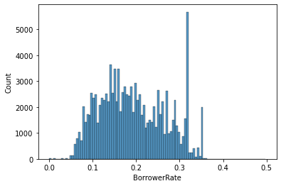

```python
sns.histplot(df_clean['BorrowerRate']);
```

Most of the interest rates range from 5% to 35%, while there is a peak around 32%.

```python
df_clean.BorrowerRate.value_counts()
```

```
0.3177    3672
0.3500    1905
0.3199    1651
0.2900    1508
0.2699    1314
          ...
0.2717       1
0.1732       1
0.1704       1
0.1786       1
0.1721       1
Name: BorrowerRate, Length: 2294, dtype: int64
```

```python
df_clean.BorrowerRate.describe()
```

```
count    113061.000000
mean          0.192946
std           0.074917
min           0.000000
25%           0.134000
50%           0.184000
75%           0.250600
max           0.497500
Name: BorrowerRate, dtype: float64
```

The highest interest rate in records is 49.75% while the lowest is 0%. The mode of interest rate is 31.77%.

### 3.3 Loan Term

```python
df_clean.Term.value_counts()
```

```
36    87219
60    24228
12     1614
Name: Term, dtype: int64
```

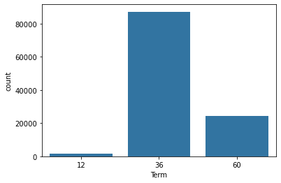

```python
sns.countplot(x=df_clean['Term'],color=base_color);
```

There's only three kinds of terms in database, namely 12 months, 36 months and 60 months. Most of the loans have a term of 36 months.

### 3.4 Credit Score Range

There are two columns presenting credit score range: CreditScoreRangeLower and CreditScoreRangeUpper.

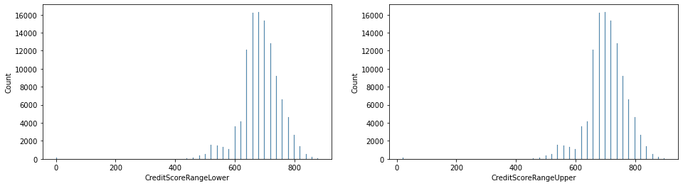

```python
# Resize the chart, and have two plots side-by-side
# Set a larger figure size for subplots
plt.figure(figsize = [16, 4])

# 1 row, 2 cols, subplot 1
plt.subplot(1, 2, 1)
sns.histplot(df_clean['CreditScoreRangeLower']);

# histogram on right, 1 row, 2 cols, subplot 2
plt.subplot(1, 2, 2)
sns.histplot(df_clean['CreditScoreRangeUpper']);
```

In both the plots, most of the credit scores range between 600 to 800. I'll check the difference of the upper and lower to see whether I should create an average score for it.

```python
# Calculate the difference
(df_clean['CreditScoreRangeUpper']-df_clean['CreditScoreRangeLower']).value_counts()
```

```
19.0    112471
dtype: int64
```

Each of the credit score ranges has a difference of 19. Then a variable 'CreditScore' will be generated based on the upper and lower variables.

```python
# Check null values of the variables
print(df_clean.CreditScoreRangeUpper.isnull().sum())
print(df_clean.CreditScoreRangeLower.isnull().sum())
```

```
590
590
```

There are 590 entries without credit score range, which will be dropped.

```python
# create a datafram for these null values
df_null_credit = df_clean[df_clean.CreditScoreRangeUpper.isnull()] # Step 1
# Drop data without credit score range
df_clean.drop(df_null_credit.index, axis=0, inplace=True)
# Check
print(df_clean.CreditScoreRangeUpper.isnull().sum())
print(df_clean.CreditScoreRangeLower.isnull().sum())
```

```
0
0
```

```python
# Generate new variables
df_clean['CreditScore'] = (df_clean['CreditScoreRangeUpper']+df_clean['CreditScoreRangeLower'])/2

# Drop the useless columns
df_clean.drop(columns=['CreditScoreRangeUpper', 'CreditScoreRangeLower'], inplace=True)
```

```python
# Check
df_clean.CreditScore
```

```
0         649.5
1         689.5
2         489.5
3         809.5
4         689.5
          ...
113932    709.5
113933    709.5
113934    709.5
113935    689.5
113936    689.5
Name: CreditScore, Length: 112471, dtype: float64
```

```python
df_clean.CreditScore.value_counts()
```

```
689.5    16315
669.5    16177
709.5    15315
729.5    12796
649.5    12098
749.5     9211
769.5     6566
789.5     4607
629.5     4172
609.5     3601
809.5     2636
529.5     1592
549.5     1474
829.5     1408
569.5     1357
589.5     1125
849.5      567
509.5      553
489.5      346
869.5      212
469.5      141
9.5        133
449.5       36
889.5       27
429.5        5
369.5        1
Name: CreditScore, dtype: int64
```

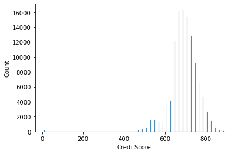

```python
sns.histplot(df_clean['CreditScore']);
```

Most of the credit score range 600 to 800, while there're some records with credit score below 400. I will plot credit score > 400 and < 400 seperately.

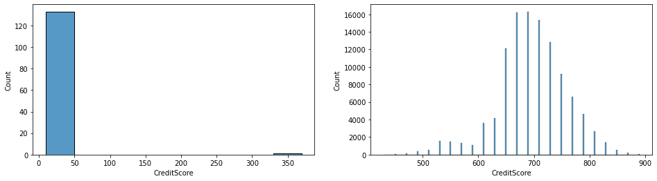

```python
# Generate two Dataframe

df_low_credit = df_clean[df_clean['CreditScore']<400]
df_high_credit = df_clean[df_clean['CreditScore']>=400]
# Resize the chart, and have two plots side-by-side
# Set a larger figure size for subplots
plt.figure(figsize = [16, 4])

# 1 row, 2 cols, subplot 1
plt.subplot(1, 2, 1)
sns.histplot(df_low_credit['CreditScore']);

# histogram on right, 1 row, 2 cols, subplot 2
plt.subplot(1, 2, 2)
sns.histplot(df_high_credit['CreditScore']);
```

133 borrowers have a credit score of 9.5. As 9.5 is far away from the main part of the distribution, these records will be removed.

```python
# Drop data with credit score = 9.5
df_clean = df_clean[df_clean['CreditScore']>9.5]

# Check
df_clean.CreditScore.min()
```

```
369.5
```

### 3.5 Listing Category

The category of the listing that the borrower selected when posting their listing: 0 - Not Available, 1 - Debt Consolidation, 2 - Home Improvement, 3 - Business, 4 - Personal Loan, 5 - Student Use, 6 - Auto, 7- Other, 8 - Baby&Adoption, 9 - Boat, 10 - Cosmetic Procedure, 11 - Engagement Ring, 12 - Green Loans, 13 - Household Expenses, 14 - Large Purchases, 15 - Medical/Dental, 16 - Motorcycle, 17 - RV, 18 - Taxes, 19 - Vacation, 20 - Wedding Loans. **This variable will be first changed from number to detailed string.**

```python
df_clean.loc[df_clean.ListingCategory==0,'ListingCategory']='Not Available'
df_clean.loc[df_clean.ListingCategory==1,'ListingCategory']='Debt Consolidation'
df_clean.loc[df_clean.ListingCategory==2,'ListingCategory']='Home Improvement'
df_clean.loc[df_clean.ListingCategory==3,'ListingCategory']='Business'
df_clean.loc[df_clean.ListingCategory==4,'ListingCategory']='Personal Loan'
df_clean.loc[df_clean.ListingCategory==5,'ListingCategory']='Student Use'
df_clean.loc[df_clean.ListingCategory==6,'ListingCategory']='Auto'
df_clean.loc[df_clean.ListingCategory==7,'ListingCategory']='Other'
df_clean.loc[df_clean.ListingCategory==8,'ListingCategory']='Baby&Adoption'
df_clean.loc[df_clean.ListingCategory==9,'ListingCategory']='Boat'
df_clean.loc[df_clean.ListingCategory==10,'ListingCategory']='Cosmetic Procedure'
df_clean.loc[df_clean.ListingCategory==11,'ListingCategory']='Engagement Ring'
df_clean.loc[df_clean.ListingCategory==12,'ListingCategory']='Green Loans'
df_clean.loc[df_clean.ListingCategory==13,'ListingCategory']='Household Expenses'
df_clean.loc[df_clean.ListingCategory==14,'ListingCategory']='Large Purchases'
df_clean.loc[df_clean.ListingCategory==15,'ListingCategory']='Medical/Dental'
df_clean.loc[df_clean.ListingCategory==16,'ListingCategory']='Motorcycle'
df_clean.loc[df_clean.ListingCategory==17,'ListingCategory']='RV'
df_clean.loc[df_clean.ListingCategory==18,'ListingCategory']='Taxes'
df_clean.loc[df_clean.ListingCategory==19,'ListingCategory']='Vacation'
df_clean.loc[df_clean.ListingCategory==20,'ListingCategory']='Wedding Loans'
```

```python
category_count = df_clean.ListingCategory.value_counts()
# Get index of ordered series
category_order = category_count.index

# Returns the sum of all not-null values in category column
n_loans = category_count.sum()

# Return the highest frequency in the category column
max_category_count = category_count[0]

# Return the maximum proportion, or in other words,
# compute the length of the longest bar in terms of the proportion
max_category_prop = max_category_count / n_loans

max_category_prop
```

```
0.5129430824832203
```

```python
# Use numpy.arange() function to produce a set of evenly spaced proportioned values
tick_props = np.arange(0, max_category_prop, 0.1)
tick_props
```

```
array([0. , 0.1, 0.2, 0.3, 0.4, 0.5])
```

```python
# Set tick labels.
tick_names = ['{:0.2f}'.format(v) for v in tick_props]
tick_names
```

```
['0.00', '0.10', '0.20', '0.30', '0.40', '0.50']
```

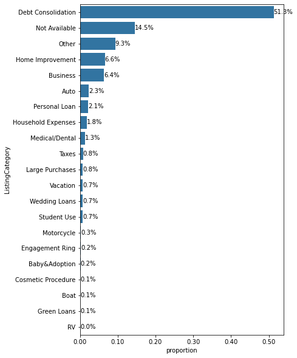

```python
plt.figure(figsize = [6, 10])

# Plot the proportions
sns.countplot(data=df_clean,y='ListingCategory', color=base_color,order=category_order);
plt.xticks(tick_props * n_loans, tick_names)
plt.xlabel('proportion');

# Logic to print the proportion text on the bars
for i in range (category_count.shape[0]):
    # Remember, type_counts contains the frequency of unique values in the `ListingCategory` column in decreasing order.
    count = category_count[i]
    # Convert count into a percentage, and then into string
    pct_string = '{:0.1f}%'.format(100*count/n_loans)
    # Print the string value on the bar.
    plt.text(count+1, i, pct_string, va='center')
```

Most of the loans are for Debt consolidation. Some other top loan aims are home improvement and business.

### 3.6 Employment Status

```python
df_clean.EmploymentStatus.value_counts()
```

```
Employed         66598
Full-time        26353
Self-employed     6052
Not available     5243
Other             3742
Part-time         1088
Not employed       835
Retired            795
Name: EmploymentStatus, dtype: int64
```

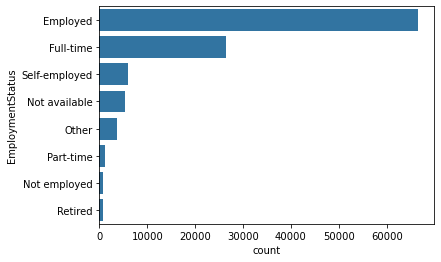

```python
# Get the indexes of the ordered Series
employ_order = df_clean.EmploymentStatus.value_counts().index

# Plot the bar chart in the decreasing order of the frequency of the `EmploymentStatus`
sns.countplot(data=df_clean, y='EmploymentStatus', color=base_color, order=employ_order);
```

Most of the borrowers are employed.

### 3.7 Income

There are three variables regarding income, namely IncomeRange, IncomeVerifiable and StatedMonthlyIncome.

(1) IncomeRange

```python
# Change to category dtype first
income_type = CategoricalDtype(categories=['Not employed','$0','$1-24,999','$25,000-49,999','$50,000-74,999','$75,000-99,999','$100,000+','Not displayed'], ordered=True)

df_clean['IncomeRange'] = df_clean['IncomeRange'].astype(income_type)

# Check
df_clean['IncomeRange']
```

```
0         $25,000-49,999
1         $50,000-74,999
2          Not displayed
3         $25,000-49,999
4              $100,000+
               ...
113932    $50,000-74,999
113933    $75,000-99,999
113934    $25,000-49,999
113935    $25,000-49,999
113936    $50,000-74,999
Name: IncomeRange, Length: 112338, dtype: category
Categories (8, object): ['Not employed' < '$0' < '$1-24,999' < '$25,000-49,999' < '$50,000-74,999' < '$75,000-99,999' < '$100,000+' < 'Not displayed']
```

```python
df_clean.IncomeRange.value_counts()
```

```
$25,000-49,999    31939
$50,000-74,999    30749
$100,000+         17188
$75,000-99,999    16780
$1-24,999          7241
Not displayed      7014
Not employed        806
$0                  621
Name: IncomeRange, dtype: int64
```

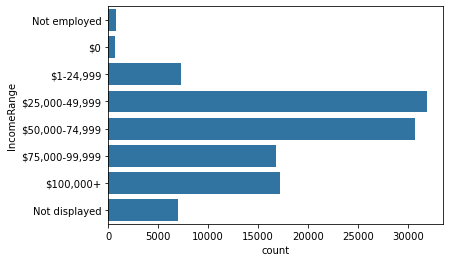

```python
# Plot the bar chart in the decreasing order of the frequency of the `IncomeRange`
sns.countplot(data=df_clean, y='IncomeRange', color=base_color);
```

The majority of the borrowers earn 25,000 to 74,999 dollars yearly.

(2) IncomeVerifiable

```python
df_clean.IncomeVerifiable.value_counts()
```

```
True     103769
False      8569
Name: IncomeVerifiable, dtype: int64
```

```python
df_clean.IncomeVerifiable.value_counts()[1]/ df_clean.IncomeVerifiable.value_counts().sum()
```

```
0.923721269739536
```

92% of the income of the borrowers are verifiable.

(3) StatedMonthlyIncome

```python
# round the income to 0-digit
df_clean['StatedMonthlyIncome']= round(df_clean['StatedMonthlyIncome']).astype(int)
df_clean['StatedMonthlyIncome'].describe()
```

```
count    1.123380e+05
mean     5.606644e+03
std      7.507990e+03
min      0.000000e+00
25%      3.207000e+03
50%      4.667000e+03
75%      6.833000e+03
max      1.750003e+06
Name: StatedMonthlyIncome, dtype: float64
```

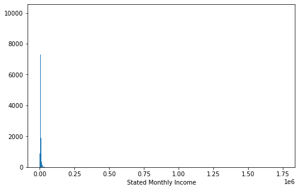

```python
# start with a standard-scaled plot
binsize = 500
bins = np.arange(0, df_clean['StatedMonthlyIncome'].max()+binsize, binsize)

plt.figure(figsize=[8, 5])
plt.hist(data = df_clean, x = 'StatedMonthlyIncome', bins = bins)
plt.xlabel('Stated Monthly Income')
plt.show()
```

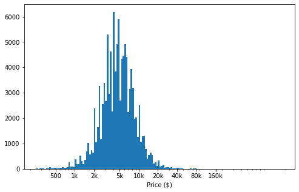

```python
# there's a long tail in the distribution, so let's put it on a log scale instead
log_binsize = 0.025
bins = 10 ** np.arange(2.4, np.log10(df_clean['StatedMonthlyIncome'].max())+log_binsize, log_binsize)

plt.figure(figsize=[8, 5])
plt.hist(data = df_clean, x = 'StatedMonthlyIncome', bins = bins)
plt.xscale('log')
plt.xticks([500, 1e3, 2e3, 5e3, 1e4, 2e4, 4e4, 8e4, 16e4], [500, '1k', '2k', '5k', '10k', '20k','40k','80k','160k'])
plt.xlabel('Price ($)')
plt.show()
```

Stated monthly income has a long-tailed distribution, with a lot of borrower on the low income end, and few on the high income end. When plotted on a log-scale, the income distribution looks normal, with one peak around 5,000. Most of the borrowers earn 2,000 to 9,000 monthly, consistent with previous analysis regarding yearly-income. There should be extreme values in the above plot. Check these above 160,000.

```python
df_clean[df_clean['StatedMonthlyIncome']>160000]
```

|  | ListingKey | ListingCreationDate | Term | Status | LoanStatus | BorrowerRate | ListingCategory | BorrowerState | ProsperRating | EmploymentStatus | EmploymentStatusDuration | IsBorrowerHomeowner | InquiriesLast6Months | DelinquenciesLast7Years | DebtToIncomeRatio | IncomeRange | IncomeVerifiable | StatedMonthlyIncome | LoanOriginalAmount | LoanOriginationDate | MonthlyLoanPayment | CreditScore |
| --- | --- | --- | --- | --- | --- | --- | --- | --- | --- | --- | --- | --- | --- | --- | --- | --- | --- | --- | --- | --- | --- | --- |
| 8066 | 37043512916744588463B5A | 2011-04-02 13:58:32.227 | 36 | Completed | Completed | 0.3199 | Debt Consolidation | IL | HR | Employed | 183.0 | True | 2.0 | 2.0 | 0.00 | $100,000+ | True | 416667 | 2000 | 2011-04-26 | 87.10 | 669.5 |
| 8870 | 44C03374833179521CEFD7D | 2006-11-26 00:25:07.540 | 36 | Defaulted | Chargedoff | 0.1200 | Not Available | CT | NaN | Not available | NaN | True | 1.0 | 0.0 | 0.01 | Not displayed | True | 208333 | 12500 | 2006-12-12 | 415.18 | 749.5 |
| 17411 | 873B351262140884511D81C | 2011-04-08 21:58:21.847 | 36 | Completed | Completed | 0.3199 | Debt Consolidation | HI | E | Employed | 121.0 | True | 4.0 | 5.0 | 0.00 | $100,000+ | True | 483333 | 7500 | 2011-05-06 | 326.62 | 669.5 |
| 53014 | F5D13567265432980C80C7D | 2013-01-04 20:02:24.207 | 12 | Completed | Completed | 0.1795 | Business | CA | D | Self-employed | 117.0 | True | 0.0 | 3.0 | NaN | $100,000+ | False | 618548 | 4000 | 2013-01-23 | 366.62 | 729.5 |
| 53167 | F9AD3540233111834F3D8A0 | 2012-02-20 12:53:44.577 | 36 | Current | Current | 0.3177 | Business | OR | HR | Self-employed | 114.0 | True | 1.0 | 0.0 | NaN | $100,000+ | False | 1750003 | 4000 | 2012-02-24 | 173.71 | 749.5 |
| 56867 | B7FC33861182547660E2E00 | 2007-04-06 18:12:51.793 | 36 | Completed | Completed | 0.1045 | Not Available | NC | NaN | Self-employed | 8.0 | True | 2.0 | 1.0 | 0.01 | $100,000+ | True | 185082 | 25000 | 2007-04-18 | 811.97 | 829.5 |
| 57133 | BF643510331462185E12917 | 2011-03-24 14:50:00.220 | 36 | Current | Current | 0.3199 | Home Improvement | CT | E | Employed | 271.0 | True | 1.0 | 0.0 | 0.00 | $100,000+ | True | 466667 | 4000 | 2011-04-05 | 174.20 | 689.5 |
| 82831 | 60723558334981883FF3663 | 2012-09-11 23:56:44.900 | 36 | Current | Current | 0.2710 | Debt Consolidation | WA | E | Self-employed | 137.0 | True | 0.0 | 0.0 | NaN | $100,000+ | False | 250000 | 4000 | 2012-09-21 | 163.52 | 709.5 |
| 83697 | 1FCB33802527950304EB984 | 2007-02-05 18:37:03.927 | 36 | Completed | Completed | 0.0800 | Not Available | NC | NaN | Not available | NaN | True | 0.0 | 1.0 | 0.00 | Not displayed | True | 185082 | 5000 | 2007-02-15 | 156.68 | 849.5 |
| 113270 | D3AF357238727540198D36B | 2013-02-20 19:23:37.430 | 36 | Current | Current | 0.1899 | Other | CA | C | Employed | 173.0 | False | 0.0 | 0.0 | 0.00 | $100,000+ | True | 394400 | 2000 | 2013-02-26 | 73.30 | 689.5 |

There're 10 borrower earn more than 160,000 monthly, which should be treated as outliers. Thus they should be removed.

```python
# Drop income > 160,000
df_clean=df_clean[df_clean['StatedMonthlyIncome']<=160000]

# Check
df_clean['StatedMonthlyIncome'].max()
```

```
158333
```

### 3.8 Debt-To-Income Ratio

```python
df_clean.DebtToIncomeRatio.describe()
```

```
count    103926.000000
mean          0.276913
std           0.555013
min           0.000000
25%           0.140000
50%           0.220000
75%           0.320000
max          10.010000
Name: DebtToIncomeRatio, dtype: float64
```

```python
df_clean[df_clean.DebtToIncomeRatio<1].shape[0]/df_clean.shape[0]
```

```
0.9179990741400185
```

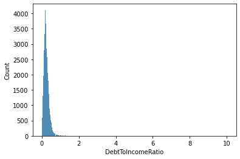

```python
sns.histplot(df_clean['DebtToIncomeRatio']);
```

91.8% of the borrowers have a debt-to-income ratio under 100%. Ratio < 1 and >= 1 will plot seperately.

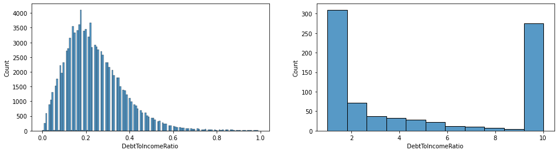

```python
# Generate two Dataframe
df_low_ratio = df_clean[df_clean['DebtToIncomeRatio']<1]
df_high_ratio = df_clean[df_clean['DebtToIncomeRatio']>=1]
# Resize the chart, and have two plots side-by-side
# Set a larger figure size for subplots
plt.figure(figsize = [16, 4])

# 1 row, 2 cols, subplot 1
plt.subplot(1, 2, 1)
sns.histplot(df_low_ratio['DebtToIncomeRatio']);

# histogram on right, 1 row, 2 cols, subplot 2
plt.subplot(1, 2, 2)
sns.histplot(df_high_ratio['DebtToIncomeRatio']);
```

From the above right figure, those with debt-to-income ratio of 10.01 should be removed as outliers.

```python
# drop ratio >=10
df_clean = df_clean[df_clean.DebtToIncomeRatio!=10.01]

# Check
df_clean.DebtToIncomeRatio.max()
```

```
9.77
```

```python
df_clean.isnull().sum()
```

```
ListingKey                      0
ListingCreationDate             0
Term                            0
Status                          0
LoanStatus                      0
BorrowerRate                    0
ListingCategory                 0
BorrowerState                4818
ProsperRating               28127
EmploymentStatus             1626
EmploymentStatusDuration     6853
IsBorrowerHomeowner             0
InquiriesLast6Months           46
DelinquenciesLast7Years       334
DebtToIncomeRatio            8402
IncomeRange                     0
IncomeVerifiable                0
StatedMonthlyIncome             0
LoanOriginalAmount              0
LoanOriginationDate             0
MonthlyLoanPayment              0
CreditScore                     0
dtype: int64
```

### 3.9 Delinquencies Last 7 Years

```python
df_clean['DelinquenciesLast7Years'].describe()
```

```
count    111722.000000
mean          4.163853
std          10.166669
min           0.000000
25%           0.000000
50%           0.000000
75%           3.000000
max          99.000000
Name: DelinquenciesLast7Years, dtype: float64
```

```python
df_clean[df_clean['DelinquenciesLast7Years']==0].shape[0]/df_clean.shape[0]
```

```
0.6741718426501035
```

67% of the borrowers don't have any delinquencies before. Let's plot those than have delinquencies.

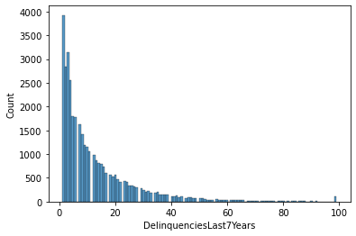

```python
df_delinquencies = df_clean[df_clean['DelinquenciesLast7Years']>0]
sns.histplot(df_delinquencies['DelinquenciesLast7Years']);
```

Most of the people with delinquencies have less than 20 times. While there's a little peak near 100 worth checking.

```python
df_delinquencies[df_delinquencies['DelinquenciesLast7Years']>90]['DelinquenciesLast7Years'].value_counts()
```

```
99.0    109
92.0      6
97.0      4
91.0      4
96.0      4
95.0      4
98.0      3
94.0      3
93.0      2
Name: DelinquenciesLast7Years, dtype: int64
```

There are 109 records with 99 in DelinquenciesLast7Years. Maybe it's because the max limit of this variable is 99. As it's not derived much from the main distribution, these data are kept.

### 3.10 Inquiries Last 6 Months

```python
df_clean['InquiriesLast6Months'].value_counts()
```

```
0.0      49484
1.0      28290
2.0      14270
3.0       7617
4.0       4256
5.0       2579
6.0       1646
7.0       1005
8.0        687
9.0        503
10.0       365
11.0       273
12.0       206
13.0       159
14.0       127
15.0        96
16.0        79
17.0        64
18.0        52
21.0        40
19.0        33
20.0        30
22.0        21
23.0        17
24.0        15
26.0        13
25.0        13
31.0        10
28.0         8
27.0         8
29.0         6
30.0         4
35.0         4
34.0         4
32.0         4
40.0         3
37.0         3
44.0         2
38.0         2
33.0         2
41.0         1
36.0         1
97.0         1
52.0         1
53.0         1
42.0         1
105.0        1
50.0         1
63.0         1
46.0         1
Name: InquiriesLast6Months, dtype: int64
```

```python
df_clean[df_clean['InquiriesLast6Months']==0].shape[0]/df_clean.shape[0]
```

```
0.4416006282572999
```

```python
df_clean[df_clean['InquiriesLast6Months']<=5].shape[0]/df_clean.shape[0]
```

```
0.9503819518812022
```

44% of borrowers didn't have any inquiries in the past six months at the time the credit profile was pulled. 95% of people had inquiries below 5. I will plot it InquiriesLast6Months >20 and <= 10 seperately.

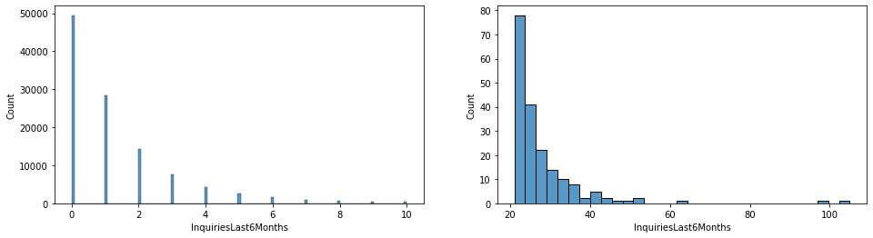

```python
# Generate two Dataframe
df_low_inquiries = df_clean[df_clean['InquiriesLast6Months']<=10]
df_high_inquiries = df_clean[df_clean['InquiriesLast6Months']>20]
# Resize the chart, and have two plots side-by-side
# Set a larger figure size for subplots
plt.figure(figsize = [16, 4])

# 1 row, 2 cols, subplot 1
plt.subplot(1, 2, 1)
sns.histplot(df_low_inquiries['InquiriesLast6Months']);

# histogram on right, 1 row, 2 cols, subplot 2
plt.subplot(1, 2, 2)
sns.histplot(df_high_inquiries['InquiriesLast6Months']);
```

It could be noticed there are two records that have extreme high inquiries (97 and 105), which will be removed as outliers.

```python
# Remove data have 97 and 105 Inquiries
df_clean = df_clean[df_clean['InquiriesLast6Months']<90]

# Check
df_clean['InquiriesLast6Months'].max()
```

```
63.0
```

### 3.11 LoanOriginalAmount

```python
df_clean['LoanOriginalAmount'].describe()
```

```
count    112008.000000
mean       8341.810156
std        6239.193569
min        1000.000000
25%        4000.000000
50%        6500.000000
75%       12000.000000
max       35000.000000
Name: LoanOriginalAmount, dtype: float64
```

```python
df_clean['LoanOriginalAmount'].value_counts()
```

```
4000     14156
15000    12214
10000    10906
5000      6860
2000      5988
         ...
6251         1
14447        1
6379         1
2345         1
4098         1
Name: LoanOriginalAmount, Length: 2451, dtype: int64
```

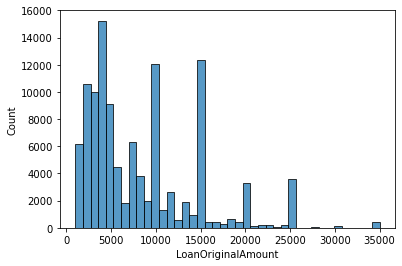

```python
sns.histplot(df_clean['LoanOriginalAmount'],bins=40);
```

Most of the loan range from 1,000 to 25,000. Besides, the amount of loan is likely to be generated by thousand as there are substantial loans with amount of 4000, 15000 and 10000.

### 3.12 MonthlyLoanPayment

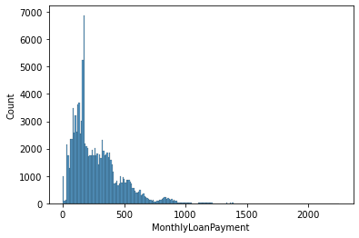

```python
sns.histplot(df_clean['MonthlyLoanPayment']);
```

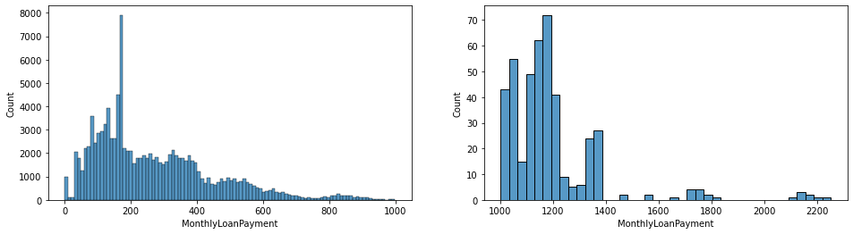

```python
# Generate two Dataframe
df_low_monthpay = df_clean[df_clean['MonthlyLoanPayment']<1000]
df_high_monthpay = df_clean[df_clean['MonthlyLoanPayment']>=1000]
# Resize the chart, and have two plots side-by-side
# Set a larger figure size for subplots
plt.figure(figsize = [16, 4])

# 1 row, 2 cols, subplot 1
plt.subplot(1, 2, 1)
sns.histplot(df_low_monthpay['MonthlyLoanPayment']);

# histogram on right, 1 row, 2 cols, subplot 2
plt.subplot(1, 2, 2)
sns.histplot(df_high_monthpay['MonthlyLoanPayment']);
```

According to above figures, we could find there're records with 0 monthly payment. Details should be checked.

```python
# Check the details
df_clean[df_clean['MonthlyLoanPayment']==0]
```

|  | ListingKey | ListingCreationDate | Term | Status | LoanStatus | BorrowerRate | ListingCategory | BorrowerState | ProsperRating | EmploymentStatus | EmploymentStatusDuration | IsBorrowerHomeowner | InquiriesLast6Months | DelinquenciesLast7Years | DebtToIncomeRatio | IncomeRange | IncomeVerifiable | StatedMonthlyIncome | LoanOriginalAmount | LoanOriginationDate | MonthlyLoanPayment | CreditScore |
| --- | --- | --- | --- | --- | --- | --- | --- | --- | --- | --- | --- | --- | --- | --- | --- | --- | --- | --- | --- | --- | --- | --- |
| 27 | 0F5034867864161084F3789 | 2010-06-16 16:23:44.533 | 36 | Completed | Completed | 0.0920 | Debt Consolidation | CO | A | Full-time | 10.0 | True | 2.0 | 0.0 | 0.26 | $75,000-99,999 | True | 6667 | 4000 | 2010-06-24 | 0.0 | 709.5 |
| 66 | 0F1D338731363098438C9F5 | 2007-04-12 17:00:57.690 | 36 | Completed | Completed | 0.1500 | Not Available | NE | NaN | Not employed | 1.0 | False | 0.0 | 12.0 | 0.20 | Not employed | True | 860 | 1000 | 2007-04-17 | 0.0 | 629.5 |
| 113 | 10CB3381860531415ABCC0F | 2007-02-23 01:40:19.853 | 36 | Completed | Completed | 0.2900 | Not Available | NaN | NaN | Self-employed | 37.0 | False | 0.0 | 25.0 | 0.04 | $50,000-74,999 | True | 4167 | 3000 | 2007-02-28 | 0.0 | 529.5 |
| 198 | 10BC3490850656956BA3148 | 2010-08-01 08:26:42.480 | 36 | Completed | Completed | 0.2575 | Other | NY | D | Employed | 3.0 | False | 2.0 | 0.0 | 0.12 | $100,000+ | True | 10000 | 3000 | 2010-08-09 | 0.0 | 669.5 |
| 310 | 09153364358698231A8518D | 2006-06-22 04:42:40.490 | 36 | Completed | Completed | 0.1175 | Not Available | SC | NaN | NaN | NaN | False | 0.0 | 5.0 | 0.16 | Not displayed | True | 3750 | 1800 | 2006-07-03 | 0.0 | 609.5 |
| ... | ... | ... | ... | ... | ... | ... | ... | ... | ... | ... | ... | ... | ... | ... | ... | ... | ... | ... | ... | ... | ... | ... |
| 113550 | FB7C34891738372088EBDF1 | 2010-07-23 18:47:30.520 | 36 | Completed | Completed | 0.1990 | Debt Consolidation | OH | C | Part-time | 12.0 | False | 0.0 | 0.0 | NaN | $1-24,999 | False | 800 | 1000 | 2010-07-30 | 0.0 | 649.5 |
| 113588 | D9613391911325872DF6CCC | 2007-06-16 15:44:53.770 | 36 | Completed | Completed | 0.1850 | Not Available | IL | NaN | Part-time | 2.0 | False | 2.0 | 51.0 | 0.50 | $1-24,999 | True | 800 | 1258 | 2007-06-26 | 0.0 | 609.5 |
| 113614 | CABD3413208203621FB889E | 2008-02-24 20:38:30.613 | 36 | Defaulted | Defaulted | 0.3500 | Debt Consolidation | MO | NaN | Full-time | 2.0 | True | 6.0 | 4.0 | 0.21 | $25,000-49,999 | True | 4000 | 1500 | 2008-03-05 | 0.0 | 529.5 |
| 113717 | CD28349694166217180A5E0 | 2010-10-17 20:45:12.530 | 36 | Completed | Completed | 0.1055 | Debt Consolidation | NY | A | Employed | 2.0 | True | 2.0 | 3.0 | 0.18 | $50,000-74,999 | True | 5073 | 4900 | 2010-10-28 | 0.0 | 769.5 |
| 113840 | DF02347078638032910ED21 | 2009-12-03 13:48:16.773 | 36 | Defaulted | Defaulted | 0.2000 | Other | NC | C | Full-time | 21.0 | False | 1.0 | 7.0 | 0.19 | $1-24,999 | True | 2000 | 1400 | 2009-12-14 | 0.0 | 669.5 |

918 rows × 22 columns

```python
# Check the terms of these loans
df_clean[df_clean['MonthlyLoanPayment']==0]['Term'].value_counts()
```

```
36    757
12    161
Name: Term, dtype: int64
```

```python
# Check the Status of these loans
df_clean[df_clean['MonthlyLoanPayment']==0]['Status'].value_counts()
```

```
Completed    787
Defaulted    131
Name: Status, dtype: int64
```

These 0 monthly payment loans all have at least 12 months loan terms. This might be due to wrong input. Check other data.

```python
df_clean[df_clean['MonthlyLoanPayment']<20]
```

|  | ListingKey | ListingCreationDate | Term | Status | LoanStatus | BorrowerRate | ListingCategory | BorrowerState | ProsperRating | EmploymentStatus | EmploymentStatusDuration | IsBorrowerHomeowner | InquiriesLast6Months | DelinquenciesLast7Years | DebtToIncomeRatio | IncomeRange | IncomeVerifiable | StatedMonthlyIncome | LoanOriginalAmount | LoanOriginationDate | MonthlyLoanPayment | CreditScore |
| --- | --- | --- | --- | --- | --- | --- | --- | --- | --- | --- | --- | --- | --- | --- | --- | --- | --- | --- | --- | --- | --- | --- |
| 27 | 0F5034867864161084F3789 | 2010-06-16 16:23:44.533 | 36 | Completed | Completed | 0.0920 | Debt Consolidation | CO | A | Full-time | 10.0 | True | 2.0 | 0.0 | 0.26 | $75,000-99,999 | True | 6667 | 4000 | 2010-06-24 | 0.00 | 709.5 |
| 66 | 0F1D338731363098438C9F5 | 2007-04-12 17:00:57.690 | 36 | Completed | Completed | 0.1500 | Not Available | NE | NaN | Not employed | 1.0 | False | 0.0 | 12.0 | 0.20 | Not employed | True | 860 | 1000 | 2007-04-17 | 0.00 | 629.5 |
| 113 | 10CB3381860531415ABCC0F | 2007-02-23 01:40:19.853 | 36 | Completed | Completed | 0.2900 | Not Available | NaN | NaN | Self-employed | 37.0 | False | 0.0 | 25.0 | 0.04 | $50,000-74,999 | True | 4167 | 3000 | 2007-02-28 | 0.00 | 529.5 |
| 117 | 0F4B341445393357179A9C5 | 2008-03-11 15:31:20.480 | 36 | Completed | Completed | 0.0885 | Debt Consolidation | CA | NaN | Part-time | 18.0 | False | 1.0 | 0.0 | 0.10 | $25,000-49,999 | True | 2500 | 2000 | 2008-03-20 | 12.97 | 749.5 |
| 198 | 10BC3490850656956BA3148 | 2010-08-01 08:26:42.480 | 36 | Completed | Completed | 0.2575 | Other | NY | D | Employed | 3.0 | False | 2.0 | 0.0 | 0.12 | $100,000+ | True | 10000 | 3000 | 2010-08-09 | 0.00 | 669.5 |
| ... | ... | ... | ... | ... | ... | ... | ... | ... | ... | ... | ... | ... | ... | ... | ... | ... | ... | ... | ... | ... | ... | ... |
| 113588 | D9613391911325872DF6CCC | 2007-06-16 15:44:53.770 | 36 | Completed | Completed | 0.1850 | Not Available | IL | NaN | Part-time | 2.0 | False | 2.0 | 51.0 | 0.50 | $1-24,999 | True | 800 | 1258 | 2007-06-26 | 0.00 | 609.5 |
| 113614 | CABD3413208203621FB889E | 2008-02-24 20:38:30.613 | 36 | Defaulted | Defaulted | 0.3500 | Debt Consolidation | MO | NaN | Full-time | 2.0 | True | 6.0 | 4.0 | 0.21 | $25,000-49,999 | True | 4000 | 1500 | 2008-03-05 | 0.00 | 529.5 |
| 113717 | CD28349694166217180A5E0 | 2010-10-17 20:45:12.530 | 36 | Completed | Completed | 0.1055 | Debt Consolidation | NY | A | Employed | 2.0 | True | 2.0 | 3.0 | 0.18 | $50,000-74,999 | True | 5073 | 4900 | 2010-10-28 | 0.00 | 769.5 |
| 113840 | DF02347078638032910ED21 | 2009-12-03 13:48:16.773 | 36 | Defaulted | Defaulted | 0.2000 | Other | NC | C | Full-time | 21.0 | False | 1.0 | 7.0 | 0.19 | $1-24,999 | True | 2000 | 1400 | 2009-12-14 | 0.00 | 669.5 |
| 113915 | D2053427325575423785798 | 2008-07-29 05:22:29.390 | 36 | Completed | Completed | 0.2000 | Other | MA | NaN | Full-time | 43.0 | True | 5.0 | 9.0 | 0.26 | $50,000-74,999 | True | 4417 | 3000 | 2008-08-06 | 1.57 | 629.5 |

1081 rows × 22 columns

There's weired monthly payment in the data, which needed further information. Therefore, this analysis will not include this variable.

```python
# Drop column
df_clean.drop(columns=['MonthlyLoanPayment'], inplace=True)
```

### 3.13 Is Borrower Homeowner

```python
df_clean['IsBorrowerHomeowner'].value_counts()
```

```
True     56913
False    55095
Name: IsBorrowerHomeowner, dtype: int64
```

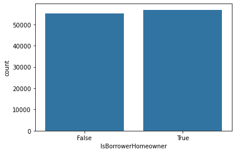

```python
sns.countplot(data=df_clean, x='IsBorrowerHomeowner', color=base_color);
```

Approximately, half of the borrowers are homeowners while the other half are not.

### 3.13 Employment Status Duration

```python
df_clean['EmploymentStatusDuration'].describe()
```

```
count    105183.000000
mean         96.149977
std          94.461078
min           0.000000
25%          26.000000
50%          67.000000
75%         137.000000
max         755.000000
Name: EmploymentStatusDuration, dtype: float64
```

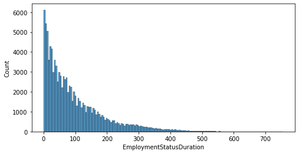

```python
# Set a larger figure size
plt.figure(figsize = [8, 4])

sns.histplot(df_clean['EmploymentStatusDuration']);
```

Most of the borrowers have a Employment Status Duration of 0-200. The max one has been employed for 755 months.

### 3.14 ProsperRating

Scale: 1 - HR, 2 - E, 3 - D, 4 - C, 5 - B, 6 - A, 7 - AA. This varible should be transformed to a category dtype with an order.

```python
# Change to category dtype
prosper_type = CategoricalDtype(categories=['HR','E','D','C','B','A','AA'], ordered=True)

df_clean['ProsperRating'] = df_clean['ProsperRating'].astype(prosper_type)

# Check
df_clean['ProsperRating']
```

```
0         NaN
1           A
2         NaN
3           A
4           D
         ...
113932      C
113933      A
113934      D
113935      C
113936      A
Name: ProsperRating, Length: 112008, dtype: category
Categories (7, object): ['HR' < 'E' < 'D' < 'C' < 'B' < 'A' < 'AA']
```

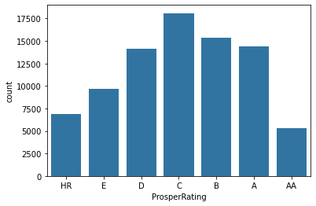

```python
# plot counts of ProsperRating

sns.countplot(data=df_clean, x='ProsperRating', color=base_color);
```

Most of the Prosper Rating of the borrowers are between D to A.

### 3.15 Log Transformation of Data

```python
df_clean.describe()
```

|  | Term | BorrowerRate | EmploymentStatusDuration | InquiriesLast6Months | DelinquenciesLast7Years | DebtToIncomeRatio | StatedMonthlyIncome | LoanOriginalAmount | CreditScore |
| --- | --- | --- | --- | --- | --- | --- | --- | --- | --- |
| count | 112008.000000 | 112008.000000 | 105183.000000 | 112008.000000 | 111720.000000 | 103652.000000 | 112008.000000 | 112008.000000 | 112008.000000 |
| mean | 40.844225 | 0.193021 | 96.149977 | 1.432639 | 4.163749 | 0.251376 | 5577.610644 | 8341.810156 | 695.915435 |
| std | 10.458262 | 0.074848 | 94.461078 | 2.399459 | 10.166730 | 0.244138 | 4202.465421 | 6239.193569 | 62.271013 |
| min | 12.000000 | 0.000000 | 0.000000 | 0.000000 | 0.000000 | 0.000000 | 0.000000 | 1000.000000 | 369.500000 |
| 25% | 36.000000 | 0.134500 | 26.000000 | 0.000000 | 0.000000 | 0.140000 | 3240.750000 | 4000.000000 | 669.500000 |
| 50% | 36.000000 | 0.184000 | 67.000000 | 1.000000 | 0.000000 | 0.220000 | 4667.000000 | 6500.000000 | 689.500000 |
| 75% | 36.000000 | 0.250600 | 137.000000 | 2.000000 | 3.000000 | 0.310000 | 6833.000000 | 12000.000000 | 729.500000 |
| max | 60.000000 | 0.360000 | 755.000000 | 63.000000 | 99.000000 | 9.770000 | 158333.000000 | 35000.000000 | 889.500000 |

### Discuss the distribution(s) of your variable(s) of interest. Were there any unusual points? Did you need to perform any transformations?

- In terms of the listing categories, the previous data used numbers. I changed it to names for better understanding.
- Regarding the loan status, there were so many types and I redefined it into three groups: Current, Completed and Defaulted.
- Credit score is presented by two variables CreditScoreRangeUpper and CreditScoreRangeLower. The range difference is 19 for each record, so a 'CreditScore' is generated based on the average of upper and lower variables.
- The StatedMonthlyIncome variable took on a large range of values, so I looked at the data using a log transform. Under the transformation, the income has a normal distribution.

### Of the features you investigated, were there any unusual distributions? Did you perform any operations on the data to tidy, adjust, or change the form of the data? If so, why did you do this?

- There's duplicated data with different ProsperScore. As there's no futher infomation to revise the dataset and this variable could be represented by ProsperRating, I decide to drop this variable and then drop the duplicated.
- There are 590 entries without credit score range. As it's an importent variable, these data were dropped. Besides, 133 borrowers have a credit score of 9.5. As 9.5 is far away from the main part of the distribution (the record higher than 9.5 is 360+), these records will be removed.
- There are 10 records in which the borrowers earn 160,000 dollars monthly. They were removed as outliers, considering they are far away from the main distributions.
- Data with debt-to-income ratio of 10.01 were removed as outliers.
- Two records have have extreme high inquiries (97 and 105), which were removed as outliers.
- There's weired monthly payment in the data (paying 0-20 dollars monthly), which needed further information. Therefore, this variable was dropped and will not be analysed.

```python
# Save the dataframe as csv file
df_clean.to_csv('cleaned_loans.csv', index=False)

# Read cleaned data
df = pd.read_csv('cleaned_loans.csv')
df.head(5)
```

|  | ListingKey | ListingCreationDate | Term | Status | LoanStatus | BorrowerRate | ListingCategory | BorrowerState | ProsperRating | EmploymentStatus | EmploymentStatusDuration | IsBorrowerHomeowner | InquiriesLast6Months | DelinquenciesLast7Years | DebtToIncomeRatio | IncomeRange | IncomeVerifiable | StatedMonthlyIncome | LoanOriginalAmount | LoanOriginationDate | CreditScore |
| --- | --- | --- | --- | --- | --- | --- | --- | --- | --- | --- | --- | --- | --- | --- | --- | --- | --- | --- | --- | --- | --- |
| 0 | 1021339766868145413AB3B | 2007-08-26 19:09:29.263 | 36 | Completed | Completed | 0.1580 | Not Available | CO | NaN | Self-employed | 2.0 | True | 3.0 | 4.0 | 0.17 | $25,000-49,999 | True | 3083 | 9425 | 2007-09-12 00:00:00.000 | 649.5 |
| 1 | 10273602499503308B223C1 | 2014-02-27 08:28:07.900 | 36 | Current | Current | 0.0920 | Home Improvement | CO | A | Employed | 44.0 | False | 3.0 | 0.0 | 0.18 | $50,000-74,999 | True | 6125 | 10000 | 2014-03-03 00:00:00.000 | 689.5 |
| 2 | 0EE9337825851032864889A | 2007-01-05 15:00:47.090 | 36 | Completed | Completed | 0.2750 | Not Available | GA | NaN | Not available | NaN | False | 0.0 | 0.0 | 0.06 | Not displayed | True | 2083 | 3001 | 2007-01-17 00:00:00.000 | 489.5 |
| 3 | 0EF5356002482715299901A | 2012-10-22 11:02:35.010 | 36 | Current | Current | 0.0974 | Motorcycle | GA | A | Employed | 113.0 | True | 0.0 | 14.0 | 0.15 | $25,000-49,999 | True | 2875 | 10000 | 2012-11-01 00:00:00.000 | 809.5 |
| 4 | 0F023589499656230C5E3E2 | 2013-09-14 18:38:39.097 | 36 | Current | Current | 0.2085 | Home Improvement | MN | D | Employed | 44.0 | True | 1.0 | 0.0 | 0.26 | $100,000+ | True | 9583 | 15000 | 2013-09-20 00:00:00.000 | 689.5 |

```python
# category dtype should be redefined
prosper_type = CategoricalDtype(categories=['HR','E','D','C','B','A','AA'], ordered=True)
df['ProsperRating'] = df['ProsperRating'].astype(prosper_type)

income_type = CategoricalDtype(categories=['Not employed','$0','$1-24,999','$25,000-49,999','$50,000-74,999','$75,000-99,999','$100,000+','Not displayed'], ordered=True)
df['IncomeRange'] = df['IncomeRange'].astype(income_type)

# Check
df.info()
```

```
<class 'pandas.core.frame.DataFrame'>
RangeIndex: 112008 entries, 0 to 112007
Data columns (total 21 columns):
 #   Column                    Non-Null Count   Dtype
---  ------                    --------------   -----
 0   ListingKey                112008 non-null  object
 1   ListingCreationDate       112008 non-null  object
 2   Term                      112008 non-null  int64
 3   Status                    112008 non-null  object
 4   LoanStatus                112008 non-null  object
 5   BorrowerRate              112008 non-null  float64
 6   ListingCategory           112008 non-null  object
 7   BorrowerState             107203 non-null  object
 8   ProsperRating             83929 non-null   category
 9   EmploymentStatus          110387 non-null  object
 10  EmploymentStatusDuration  105183 non-null  float64
 11  IsBorrowerHomeowner       112008 non-null  bool
 12  InquiriesLast6Months      112008 non-null  float64
 13  DelinquenciesLast7Years   111720 non-null  float64
 14  DebtToIncomeRatio         103652 non-null  float64
 15  IncomeRange               112008 non-null  category
 16  IncomeVerifiable          112008 non-null  bool
 17  StatedMonthlyIncome       112008 non-null  int64
 18  LoanOriginalAmount        112008 non-null  int64
 19  LoanOriginationDate       112008 non-null  object
 20  CreditScore               112008 non-null  float64
dtypes: bool(2), category(2), float64(6), int64(3), object(8)
memory usage: 15.0+ MB
```

## 4. Bivariate Exploration

To start off with, I want to look at the pairwise correlations present between features in the data.

```python
numeric_vars = ['BorrowerRate', 'EmploymentStatusDuration', 'InquiriesLast6Months', 'DelinquenciesLast7Years', 'DebtToIncomeRatio', 'StatedMonthlyIncome','LoanOriginalAmount','CreditScore']
categoric_vars = ['Status', 'IsBorrowerHomeowner','EmploymentStatus','IncomeVerifiable','IncomeRange','Term','ProsperRating']
```

### 4.1 General plotting

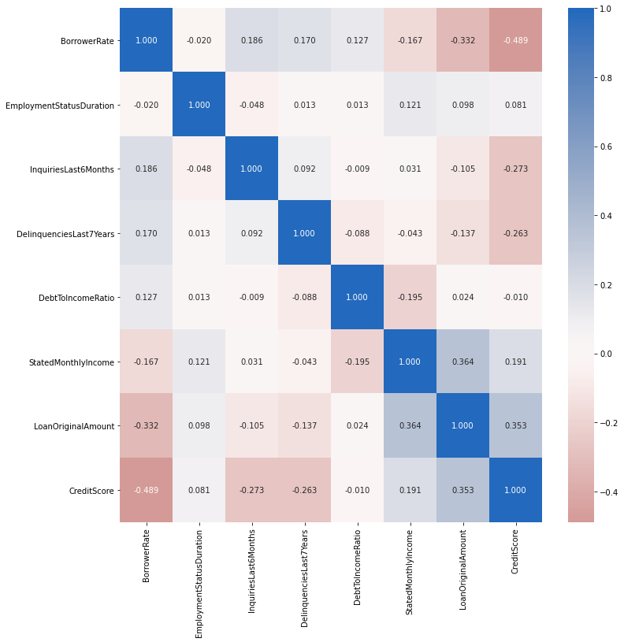

```python
# correlation plot
plt.figure(figsize = [12, 12])
sns.heatmap(df[numeric_vars].corr(), annot = True, fmt = '.3f',
           cmap = 'vlag_r', center = 0)
plt.show()
```

From above figure, we could see borrow rate might have a negative relationship with Stated monthly income, loan original amount and credit score. It might have a positive correlation with inquries last 6 months and delinquencies last 7 years. This need futher Investigation.

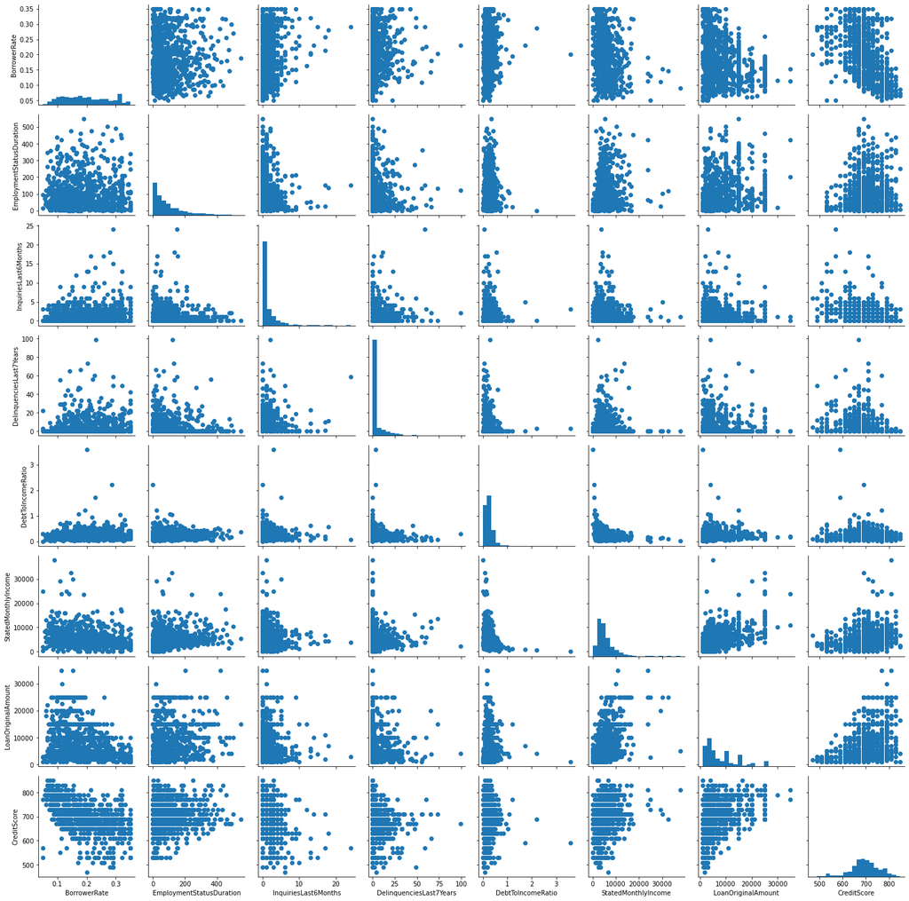

```python
# plot matrix: sample 1000 records so that plots are clearer and
# they render faster
samples = np.random.choice(df.shape[0], 1000, replace = False)
df_samp = df.loc[samples,:]

g = sns.PairGrid(data = df_samp, vars = numeric_vars)
g = g.map_diag(plt.hist, bins = 20);
g.map_offdiag(plt.scatter);
```

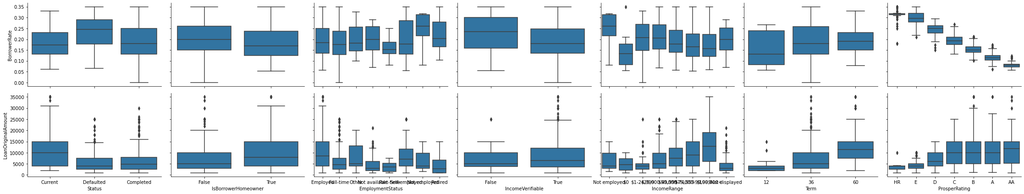

```python
# plot matrix of numeric features against categorical features.
# can use a larger sample since there are fewer plots and they're simpler in nature.

samples = np.random.choice(df.shape[0], 2000, replace = False)
df_samp = df.loc[samples,:]

def boxgrid(x, y, **kwargs):
    """ Quick hack for creating box plots with seaborn's PairGrid. """
    default_color = sns.color_palette()[0]
    sns.boxplot(x, y, color = default_color)

plt.figure(figsize = [10, 10])
g = sns.PairGrid(data = df_samp, y_vars = ['BorrowerRate', 'LoanOriginalAmount'], x_vars = categoric_vars,
                size = 3, aspect = 1.5)
g.map(boxgrid)
plt.show();
```

Interestingly, it appears that there are some negative relationships between the categorical variables and the two numeric variables of interest. Moreover, the relationship between categorical variable and Borrower Rate seems opposite to the relationship between categorical variable and Loan Original Amount.

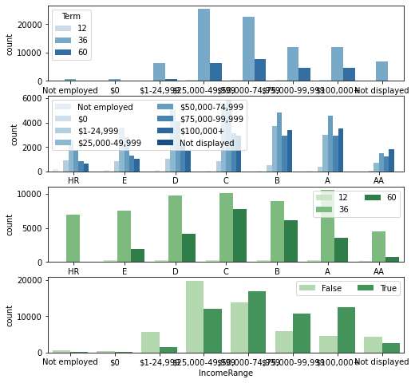

```python
# categoric_vars = ['Status', 'IsBorrowerHomeowner','EmploymentStatus',
#'IncomeVerifiable','IncomeRange','Term','ProsperRating']
# since there's only three subplots to create, using the full data should be fine.
plt.figure(figsize = [8, 8])

# subplot 1: IncomeRange vs Term
plt.subplot(4, 1, 1)
sns.countplot(data = df, x = 'IncomeRange', hue = 'Term', palette = 'Blues')

# subplot 2: ProsperRating vs. IncomeRange
ax = plt.subplot(4, 1, 2)
sns.countplot(data = df, x = 'ProsperRating', hue = 'IncomeRange', palette = 'Blues')
ax.legend(loc = 2, ncol = 2) # re-arrange legend to reduce overlapping

# subplot 3: ProsperRating vs. Term, use different color palette
ax = plt.subplot(4, 1, 3)
sns.countplot(data = df, x = 'ProsperRating', hue = 'Term', palette = 'Greens')
ax.legend(loc = 1, ncol = 2) # re-arrange legend to remove overlapping


# subplot 4: IncomeRange vs. IncomeVerifiable, use different color palette
ax = plt.subplot(4, 1, 4)
sns.countplot(data = df, x = 'IncomeRange', hue = 'IsBorrowerHomeowner', palette = 'Greens')
ax.legend(loc = 1, ncol = 2) # re-arrange legend to remove overlapping
plt.show()
```

### 4.2 Borrower rate vs. stated monthly income

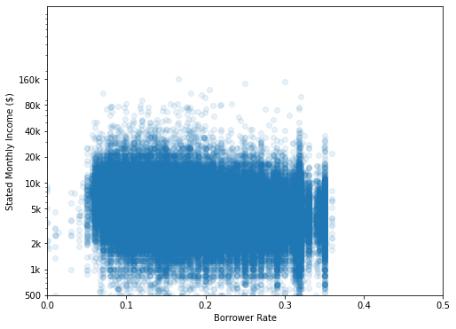

```python
# scatter plot of price vs. carat, with log transform on price axis
plt.figure(figsize = [8, 6])
plt.scatter(data = df, x = 'BorrowerRate', y = 'StatedMonthlyIncome', alpha = 1/10)
plt.xlim([0, 0.5])
plt.xlabel('Borrower Rate')
plt.yscale('log')
plt.yticks([500, 1e3, 2e3, 5e3, 1e4, 2e4, 4e4, 8e4, 16e4], [500, '1k', '2k', '5k', '10k', '20k', '40k', '80k','160k'])
plt.ylabel('Stated Monthly Income ($)')
plt.show()
```

There might no correlation between borrower rate and stated monthly income.

### 4.3 Borrow rate vs credit score

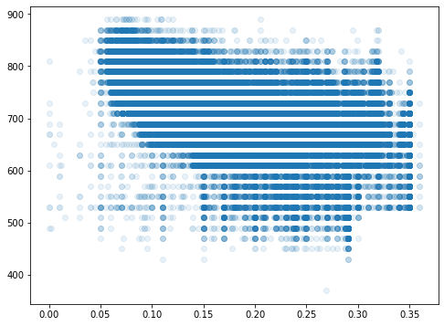

```python
plt.figure(figsize = [8, 6])
plt.scatter(data = df, x = 'BorrowerRate', y = 'CreditScore', alpha = 1/10);
```

Borrow rate and credit score are negatively correlated.

### 4.4 Borrow rate vs loan original amount

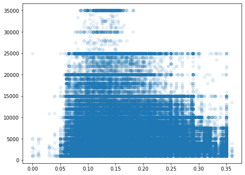

```python
plt.figure(figsize = [8, 6])
plt.scatter(data = df, x = 'BorrowerRate', y = 'LoanOriginalAmount', alpha = 1/10);
```

The relationship worths further analysis.

### 4.5 Loan’s outcome status vs Income range

To analysis loan outcome status, we need to generate a new dataframe only include data either completed or defaulted.

```python
# Generate a new dataframe only include data either completed or defaulted
df_status = df[df['Status']!='Current']
# Check
df_status.shape
```

```
(56305, 21)
```

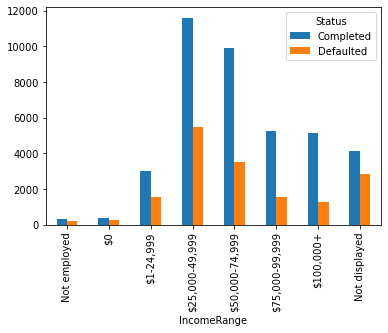

```python
# generate data of 'Status', 'IncomeRange'
income_defaulted = df_status.groupby(['Status', 'IncomeRange'])['Status'].count().unstack(0)
# Plot 'Status', 'IncomeRange'
income_defaulted.plot(kind='bar');
```

There's not much information. Below plots the defaulted rate for each group.

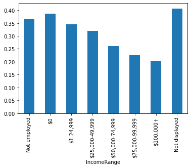

```python
income_defaulted_rate = (income_defaulted['Defaulted'] / (income_defaulted['Defaulted'] + income_defaulted['Completed']))
income_defaulted_rate.plot(kind='bar');
```

It can be discovered that the higher the income range, the lower the defaulted rate.